# Hypothesis Testing

## Directions

Today we will revisit our crawdad dataset, this time to address one exploration question and two hypotheses, given below. You are welcome to use any of the labs, homework, or course resources for this project.

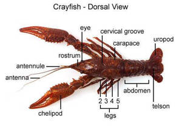

#### Exploration Question

For future studies, we wish to get a sense of the average length of a female crawdad carapace, measured in centimeters. Using the data provided, report the average female crawdad carapace length, its standard deviation, and give a 90% confidence interval for the true value

#### Hypothesis 1

Two students were asked to guess the average claw length of a collection of crawdad, grouped by sex. The two hypotheses are given below:

1. $H_{01}:$ The average claw length of a male crawdad is $\mu = 4.54$ cm
2. $H_{02}:$ The average claw length of a female crawdad is $\mu = 3.62$ cm

We are interested in knowing for which hypothesis do we have more evidence against the null. Perform any tests necessary to determine this and justify any conclusion you make.

#### Hypothesis 2

Next, we are interested in investigating whether crawdad size plays a differential role in the presence of injuries for males. Start by constructing a new variable `size` that takes the value `"large"` if a given crawdad has a larger weight than the *average of its sex* and `"small"` otherwise. Then determine the proportion of males with indication of any injury for both small and large crawdads.

Is there evidence that the proportion of males with any injury is different between large and small crawdads? Report your conclusions with 90% confidence.

A successful report will include the following:

- Include headers using “#” for each of the problems
- Show computations in your code for of the hypotheses
- Use complete sentences to report your answer
- Add your name at the top

Once you are finished, Knit the document to a PDF and assess whether or not it looks and reads like something you would feel comfortable sending to a professional collaborator. Once you are satisfied with your document, submit it to Gradescope.